# Ch05 未整理形式への変換

これまでは整理データのみを扱ってきた. 実際には整理データではない, 未構造化データを扱うことが多く, そのためのパッケージも多数用意されている. 大事なのは`glue`, つまりデータ構造を結び付けることである.

# ライブラリー

```r
config <- yaml::read_yaml("config.yaml")
for (p in config$LIBS$CRAN) {
  if (!require(p, character.only = TRUE)) {
    install.packages(p)
  }
  require(p, character.only = TRUE)
}
```

# DTMの整理

DTM(文書-単語行列)はテキストマイニングの操作対象として 最も広く使われているデータ構造の１つで, 次ぎのような 特徴を持っている.

- 各行は1つの文書を表します
- 各列は1つの単語を表します
- 個々の値は, (一般に)その単語の文書内における出現頻度である

文書と単語の組み合わせでみると, ほとんどが0であるので, DTMは疎行列として実装されるのが通常である.

tidytextパッケージではDTMと整理データを相互変換する 関数を用意している.

- tidy: DTM→整理データ
- cast: ユニグラムの整理データをDTMに

## DTMオブジェクトの整理

最もメジャーなのはtmパッケージの`DocumentTermMatrix`クラスである.

```r
data("AssociatedPress", package = "topicmodels")

AssociatedPress
```

```
## <<DocumentTermMatrix (documents: 2246, terms: 10473)>>
## Non-/sparse entries: 302031/23220327
## Sparsity           : 99%
## Maximal term length: 18
## Weighting          : term frequency (tf)
```

```r
# 文書内の単語にアクセス
terms <- Terms(AssociatedPress)
head(terms)
```

```
## [1] "aaron"      "abandon"    "abandoned"  "abandoning" "abbott"
## [6] "abboud"
```

DTMを整理データとして分析したいたいめ, 1行1文書1トークンという整理データを作成していく

```r
ap_td <- tidy(AssociatedPress)
ap_td %>% top_n(20)
```

| document | term | count |
| --- | --- | --- |
| 15 | percent | 28 |
| 25 | bank | 27 |
| 31 | percent | 23 |
| 132 | party | 25 |
| 219 | percent | 31 |
| 383 | german | 23 |
| 487 | estate | 27 |
| 695 | steel | 23 |
| 759 | reed | 27 |
| 869 | fair | 36 |

[output cut: 15 more lines]

この状態ならばセンチメント分析はすぐにできる

```r
ap_sentiments <-
  ap_td %>%
  inner_join(get_sentiments("bing"), by = c (term = "word"))

ap_sentiments %>% head(20)
```

| document | term | count | sentiment |
| --- | --- | --- | --- |
| 1 | assault | 1 | negative |
| 1 | complex | 1 | negative |
| 1 | death | 1 | negative |
| 1 | died | 1 | negative |
| 1 | good | 2 | positive |
| 1 | illness | 1 | negative |
| 1 | killed | 2 | negative |
| 1 | like | 2 | positive |
| 1 | liked | 1 | positive |
| 1 | miracle | 1 | positive |

[output cut: 10 more lines]

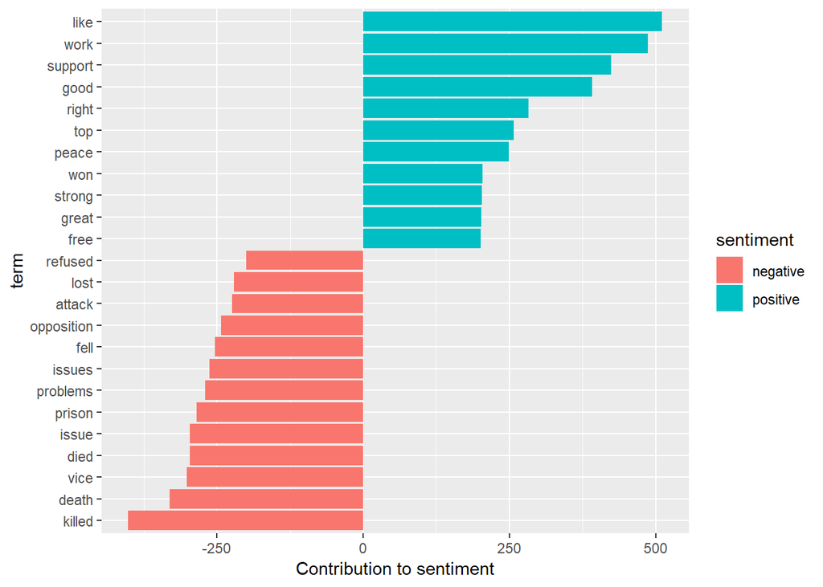

```r
ap_sentiments %>%
  count(sentiment, term, wt = count) %>%
  ungroup() %>%
  filter(n >= 200) %>%
  mutate(n = ifelse(sentiment == "negative", -n, n)) %>%
  mutate(term = reorder(term, n)) %>%
  ggplot(aes(term, n, fill = sentiment)) +
  geom_bar(stat = "identity") +
  ylab("Contribution to sentiment") +
  coord_flip()
```

## dfmオブジェクトの整理

DTMの別の実装を提供してるパッケージもある.

```r
data("data_corpus_inaugural", package = "quanteda")
inaug_dfm <-
  quanteda::dfm(data_corpus_inaugural, verbose = FALSE)

inaug_dfm
```

```
## Document-feature matrix of: 58 documents, 9,357 features (91.8% sparse).
```

tidyメソッドは, dfmオブジェクトにも対応している.

```r
inaug_td <- tidy(inaug_dfm)
inaug_td %>% top_n(20)
```

| document | term | count |
| --- | --- | --- |
| 1841-Harrison | of | 604 |
| 1845-Polk | of | 298 |
| 1909-Taft | of | 314 |
| 1929-Hoover | of | 250 |
| 1817-Monroe | the | 275 |
| 1821-Monroe | the | 360 |
| 1825-Adams | the | 304 |
| 1837-VanBuren | the | 252 |
| 1841-Harrison | the | 829 |
| 1845-Polk | the | 397 |

[output cut: 10 more lines]

それぞれの就任演説で最も特徴的な単語を探す. これは`tf-idf`分析により数量化できる.

```r
inaug_tf_idf <-
  inaug_td %>%
  bind_tf_idf(term, document, count) %>%
  arrange(desc(tf_idf))

inaug_tf_idf %>% top_n(20, tf_idf)
```

| document | term | count | tf | idf | tf_idf |
| --- | --- | --- | --- | --- | --- |
| 1793-Washington | arrive | 1 | 0.006802721 | 4.060443 | 0.02762206 |
| 1793-Washington | upbraidings | 1 | 0.006802721 | 4.060443 | 0.02762206 |
| 1793-Washington | violated | 1 | 0.006802721 | 3.367296 | 0.02290677 |
| 1793-Washington | willingly | 1 | 0.006802721 | 3.367296 | 0.02290677 |
| 1793-Washington | incurring | 1 | 0.006802721 | 3.367296 | 0.02290677 |
| 1793-Washington | previous | 1 | 0.006802721 | 2.961831 | 0.02014851 |
| 1793-Washington | knowingly | 1 | 0.006802721 | 2.961831 | 0.02014851 |
| 1793-Washington | injunctions | 1 | 0.006802721 | 2.961831 | 0.02014851 |
| 1793-Washington | witnesses | 1 | 0.006802721 | 2.961831 | 0.02014851 |
| 1793-Washington | besides | 1 | 0.006802721 | 2.674149 | 0.01819149 |

[output cut: 10 more lines]

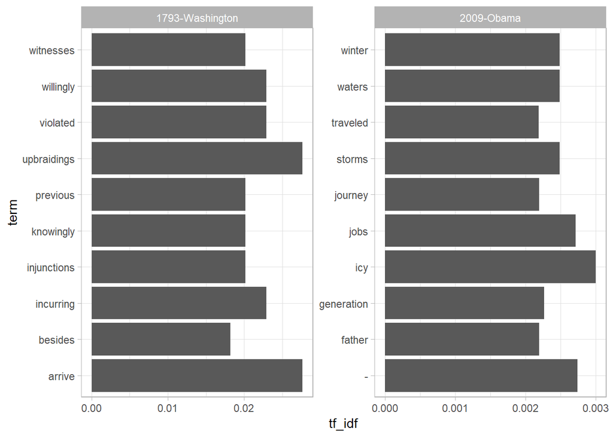

```r
inaug_tf_idf %>%
  filter(document %in% c("1793-Washington", "2009-Obama")) %>%
  group_by(document) %>%
  top_n(10, tf_idf) %>%
  arrange(desc(tf_idf)) %>%
  ungroup() %>%
  ggplot(aes(term, tf_idf)) +
  geom_col() +
  facet_wrap( ~ document, ncol = 2, scales = "free") +
  theme_light() +
  coord_flip()
```

文書から年と抽出し, 各年ごとに単語の 出現回数を計算する.

```r
# completeでyear x termの全ての組み合わせを作ってから集計
year_term_counts <-
  inaug_td %>%
  tidyr::extract(document, "year", "(\\d+)", convert = TRUE) %>%
  complete(year, term, fill = list(count = 0)) %>%
  group_by(year) %>%
  mutate(year_total = sum(count))
```

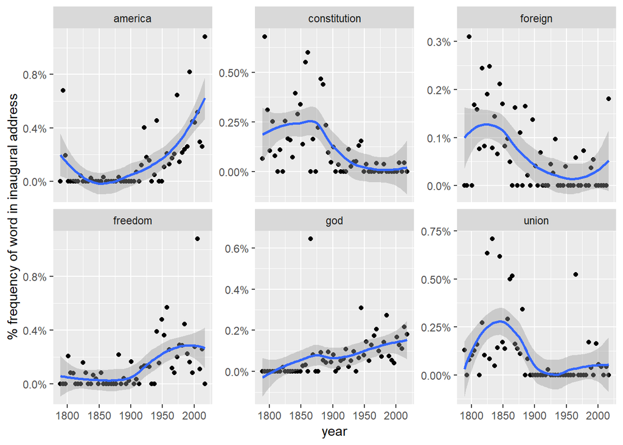

```r
year_term_counts %>%
  filter(term %in% c ("god", "america", "foreign", "union",
                      "constitution", "freedom")) %>%
  ggplot(aes(year, count / year_total)) +
  geom_point() +
  geom_smooth() +
  facet_wrap( ~ term, scales = "free_y") +
  scale_y_continuous(labels = scales::percent_format()) +
  ylab("% frequency of word in inaugural address")
```

# 整理データの行列へのキャスト

整理データからDTMへ変換を行う`cast_`を紹介する.

```r
ap_td %>%
  cast_dtm(document, term, count)
```

```
## <<DocumentTermMatrix (documents: 2246, terms: 10473)>>
## Non-/sparse entries: 302031/23220327
## Sparsity           : 99%
## Maximal term length: 18
## Weighting          : term frequency (tf)
```

`dfmオブジェクト`へでもキャストができる.

```r
ap_td %>%
  cast_dfm(document, term, count)
```

```
## Document-feature matrix of: 2,246 documents, 10,473 features (98.7% sparse).
```

純粋に疎行列に変換することも可能.

```r
m <- ap_td %>%
  cast_sparse(document, term, count)
class(m)
```

```
## [1] "dgCMatrix"
## attr(,"package")
## [1] "Matrix"
```

このため, 前章まで利用してきた整理データの サンプルデータも用意にDTM化が可能である. .

```r
austen_dtm <-
  austen_books() %>%
  unnest_tokens(word, text) %>%
  count(book, word) %>%
  cast_dtm(book, word, n)
austen_dtm
```

```
## <<DocumentTermMatrix (documents: 6, terms: 14520)>>
## Non-/sparse entries: 40379/46741
## Sparsity           : 54%
## Maximal term length: 19
## Weighting          : term frequency (tf)
```

# メタデータを持つ場合

トークン化する前の文書コレクションを格納するために 設計されたデータ構造がいくつかある. これらは「**コーパス**」と呼ばれる.

例えばtmパッケージにあるロイターの50本のニュース記事を 収録するacqコーパスを見てみる.

```r
data("acq")

acq
```

```
## <<VCorpus>>
## Metadata:  corpus specific: 0, document level (indexed): 0
## Content:  documents: 50
```

```r
# 最初の文書
acq[[1]]
```

```
## <<PlainTextDocument>>
## Metadata:  15
## Content:  chars: 1287
```

tidy関数を使うことで, **メタデータ**とともに1行1コーパスに 変換することが可能である.

```r
acq_td <- tidy(acq)
acq_td
```

| author | datetimestamp | description | heading | id | language | origin | topics | lewissplit | cgisplit | oldid | places | people | orgs | exchanges | text |
| --- | --- | --- | --- | --- | --- | --- | --- | --- | --- | --- | --- | --- | --- | --- | --- |
| NA | 1987-02-27 00:18:06 |  | COMPUTER TERMINAL SYSTEMS COMPLETES SALE | 10 | en | Reuters-21578 XML | YES | TRAIN | TRAINING-SET | 5553 |  | NA | NA | NA | Computer Terminal Systems Inc said\nit has completed the sale of 200,000 shares of its common\nstock, and warrants to acquire an additional one mln shares, to\n of Lugano, Switzerland for 50,000 dlrs.… |
| NA | 1987-02-27 00:19:15 |  | OHIO MATTRESS MAY HAVE LOWER 1ST QTR NET | 12 | en | Reuters-21578 XML | YES | TRAIN | TRAINING-SET | 5555 |  | NA | NA | NA | Ohio Mattress Co said its first\nquarter, ending February 28, profits may be below the 2.4 mln\ndlrs, or 15 cts a share, earned in the first quarter of fiscal\n1986.\n The company said any decline wou… |
| NA | 1987-02-27 00:49:56 |  | MCLEAN'S U.S. LINES SETS ASSET TRANSFER | 44 | en | Reuters-21578 XML | YES | TRAIN | TRAINING-SET | 5587 |  | NA | NA | NA | McLean Industries Inc's United\nStates Lines Inc subsidiary said it has agreed in principle to\ntransfer its South American service by arranging for the\ntransfer of certain charters and assets to 's … |
| By Cal Mankowski, Reuters | 1987-02-27 00:51:17 |  | CHEMLAWN RISES ON HOPES FOR HIGHER BIDS | 45 | en | Reuters-21578 XML | YES | TRAIN | TRAINING-SET | 5588 |  | NA | NA | NA | ChemLawn Corp could attract a\nhigher bid than the 27 dlrs per share offered by Waste\nManagement Inc , Wall Street arbitrageurs said.\n Shares of ChemLawn shot up 11-5/8 to 29-3/8 in\nover-the-counte… |
| NA | 1987-02-27 01:08:33 |  | BUYS GULFEX FOR UNDISCLOSED AMOUNT | 68 | en | Reuters-21578 XML | YES | TRAIN | TRAINING-SET | 5611 |  | NA | NA | NA | CoFAB Inc said it acquired ,\na Houston-based fabricator of custom high-pressure process\nvessels for the energy and petrochemical industries.\n CoFAB said its group of companies manufacture specializ… |
| NA | 1987-02-27 01:32:37 |  | INVESTMENT FIRMS CUT CYCLOPS STAKE | 96 | en | Reuters-21578 XML | YES | TRAIN | TRAINING-SET | 5639 |  | NA | NA | NA | A group of affiliated New York\ninvestment firms said they lowered their stake in Cyclops Corp\nto 260,500 shares, or 6.4 pct of the total outstanding common\nstock, from 370,500 shares, or 9.2 pct.\n… |
| By Patti Domm, Reuter | 1987-02-27 01:43:13 |  | AMERICAN EXPRESS SEEN IN POSSIBLE SPINNOFF | 110 | en | Reuters-21578 XML | YES | TRAIN | TRAINING-SET | 5653 |  | NA | NA | NA | American Express Co remained silent on\nmarket rumors it would spinoff all or part of its Shearson\nLehman Brothers Inc, but some analysts said the company may be\nconsidering such a move because it i… |
| NA | 1987-02-27 01:59:25 |  | HONG KONG FIRM UPS WRATHER STAKE TO 11 PCT | 125 | en | Reuters-21578 XML | YES | TRAIN | TRAINING-SET | 5668 |  | NA | NA | NA | Industrial Equity (Pacific) Ltd, a\nHong Kong investment firm, said it raised its stake in Wrather\nCorp to 816,000 shares, or 11.3 pct of the total outstanding\ncommon stock, from 453,300 shares, or … |
| NA | 1987-02-27 02:01:28 |  | LIEBERT CORP APPROVES MERGER | 128 | en | Reuters-21578 XML | YES | TRAIN | TRAINING-SET | 5671 |  | NA | NA | NA | Liebert Corp said its shareholders\napproved the merger of a wholly-owned subsidiary of Emerson\nElectric Co .\n Under the terms of the merger, each Liebert shareholder\nwill receive .3322 shares of E… |
| NA | 1987-02-27 02:08:27 |  | GULF APPLIED TECHNOLOGIES SELLS UNITS | 134 | en | Reuters-21578 XML | YES | TRAIN | TRAINING-SET | 5677 |  | NA | NA | NA | Gulf Applied Technologies Inc said it\nsold its subsidiaries engaged in pipeline and terminal\noperations for 12.2 mln dlrs.\n The company said the sale is subject to certain post\nclosing adjustments… |

[output cut: 40 more lines]

`unnest_tokens`をこの表に対して使うことで, ロイターのコーパスを整理データに変換ができる.

```r
acq_tokens <-
  acq_td %>%
  select(-places) %>%
  unnest_tokens(word, text) %>%
  anti_join(stop_words, by = "word")


# 最頻出語
acq_tokens %>%
  count(word, sort = TRUE) %>% head()
```

| word | n |
| --- | --- |
| dlrs | 100 |
| pct | 70 |
| mln | 65 |
| company | 63 |
| shares | 52 |
| reuter | 50 |

```r
# tf-idf
acq_tokens %>%
  count(id, word) %>%
  bind_tf_idf(word, id, n) %>%
  arrange(desc(tf_idf))
```

| id | word | n | tf | idf | tf_idf |
| --- | --- | --- | --- | --- | --- |
| 186 | groupe | 2 | 0.133333333 | 3.9120230 | 0.521603067 |
| 128 | liebert | 3 | 0.130434783 | 3.9120230 | 0.510263870 |
| 474 | esselte | 5 | 0.108695652 | 3.9120230 | 0.425219892 |
| 371 | burdett | 6 | 0.103448276 | 3.9120230 | 0.404692035 |
| 442 | hazleton | 4 | 0.102564103 | 3.9120230 | 0.401233129 |
| 199 | circuit | 5 | 0.102040816 | 3.9120230 | 0.399186021 |
| 162 | suffield | 2 | 0.100000000 | 3.9120230 | 0.391202301 |
| 498 | west | 3 | 0.100000000 | 3.9120230 | 0.391202301 |
| 441 | rmj | 8 | 0.121212121 | 3.2188758 | 0.390166767 |
| 467 | nursery | 3 | 0.096774194 | 3.9120230 | 0.378582871 |

[output cut: 2843 more lines]

## 株式に関する記事のマイニング

オンラインフィードに接続し, キーワードに基づいてニュース記事を読み出すパッケージを利用して, Microsft(MSFT)株に関連する記事を取得する.

```r
company <-
  c ("Microsoft", "Apple", "Google", "Amazon", "Facebook",
     "Twitter", "IBM", "Yahoo", "Netflix")
symbol <-
  c ("MSFT", "APPL", "GOOG", "AMZN", "FB", "TWTR", "IBM", "YHOO",
     "NFLX")

download_articles <- function (symbol) {
  WebCorpus(YahooFinanceSource(symbol))
}

stock_articles <-
  data_frame(
    company = company, symbol = symbol
  ) %>%
  mutate(corpus = map(symbol, download_articles))

stock_articles
```

| company | symbol | corpus |
| --- | --- | --- |
| Microsoft | MSFT |  |
| Apple | APPL |  |
| Google | GOOG |  |
| Amazon | AMZN |  |
| Facebook | FB |  |
| Twitter | TWTR |  |
| IBM | IBM |  |
| Yahoo | YHOO |  |
| Netflix | NFLX |  |

`unnest(map)`の記法は知らなかった.

```r
stock_tokens <-
  stock_articles %>%
  # with(., map(corpus, tidy)) %>% bind_rows()と
  # 同じ
  unnest(map(corpus, tidy)) %>%
  unnest_tokens(word, text) %>%
  select(company, datetimestamp, word, id, heading)

stock_tokens %>% head()
```

| company | datetimestamp | word | id | heading |
| --- | --- | --- | --- | --- |
| Microsoft | 2018-07-14 23:41:39 | microsoft | 22de4088-440c-373f-a0a5-dfdc7cece747 | Microsoft calls for government regulation to prevent abuse of facial recognition tech |
| Microsoft | 2018-07-14 23:41:39 | calls | 22de4088-440c-373f-a0a5-dfdc7cece747 | Microsoft calls for government regulation to prevent abuse of facial recognition tech |
| Microsoft | 2018-07-14 23:41:39 | for | 22de4088-440c-373f-a0a5-dfdc7cece747 | Microsoft calls for government regulation to prevent abuse of facial recognition tech |
| Microsoft | 2018-07-14 23:41:39 | government | 22de4088-440c-373f-a0a5-dfdc7cece747 | Microsoft calls for government regulation to prevent abuse of facial recognition tech |
| Microsoft | 2018-07-14 23:41:39 | regulation | 22de4088-440c-373f-a0a5-dfdc7cece747 | Microsoft calls for government regulation to prevent abuse of facial recognition tech |
| Microsoft | 2018-07-14 23:41:39 | to | 22de4088-440c-373f-a0a5-dfdc7cece747 | Microsoft calls for government regulation to prevent abuse of facial recognition tech |

トークンナイズしたので, センチメント分析を行い記事が ポイジティ部なものかどうかを判断する.

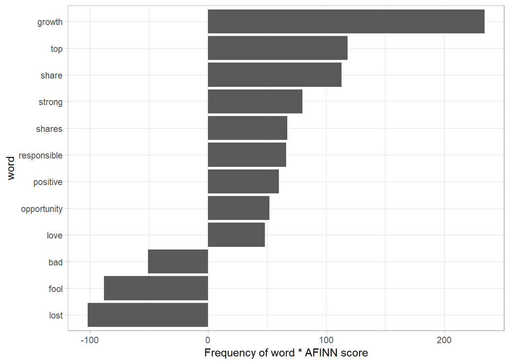

```r
stock_tokens %>%
  anti_join(stop_words, by = "word") %>%
  count(word, id, sort = TRUE) %>%
  inner_join(get_sentiments("afinn"), by = "word") %>%
  group_by(word) %>%
  summarise(contribution = sum(n * score)) %>%
  top_n(12, abs(contribution)) %>%
  mutate(word = reorder(word, contribution)) %>%
  ggplot(aes(word, contribution)) +
  geom_col() +
  coord_flip() +
  labs(y = "Frequency of word * AFINN score") +
  theme_light()
```

実は株式用語の感情はAFINNでは不適当であるので, 別の辞書を使う.

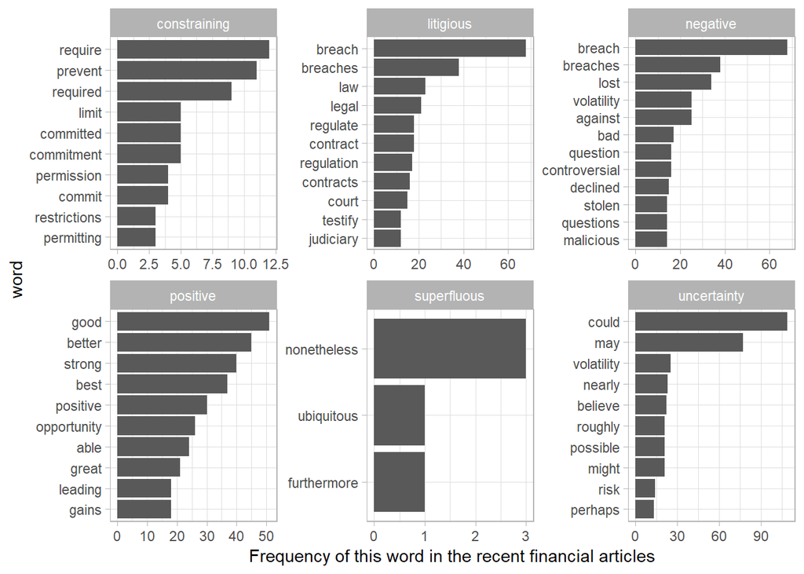

```r
stock_tokens %>%
  count(word) %>%
  inner_join(get_sentiments("loughran"), by = "word") %>%
  group_by(sentiment) %>%
  top_n(10, n) %>%
  ungroup() %>%
  mutate(word = reorder(word, n)) %>%
  ggplot(aes(word, n)) +
  geom_col() +
  coord_flip() +
  facet_wrap( ~ sentiment, scales = "free") +
  ylab("Frequency of this word in the recent financial articles") +
  theme_light()
```

上記の結果で辞書が概ね妥当なおことがわかったので, ここでは個々のコーパスに含まれる個々の 感情を表す単語の数を数える処理をおこなう.

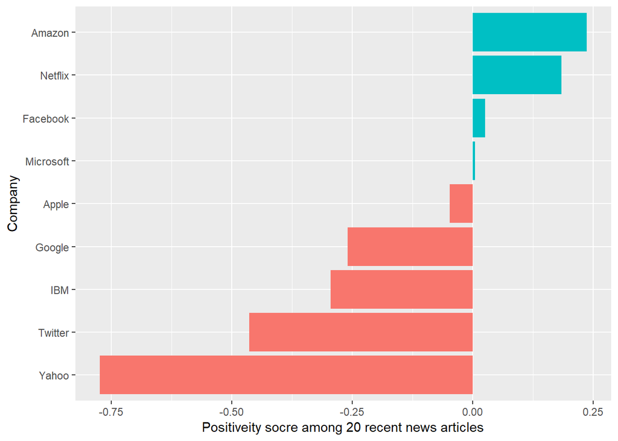

```r
stock_sentiment_count <-
  stock_tokens %>%
  inner_join(get_sentiments("loughran"), by = "word") %>%
  count(sentiment, company) %>%
  spread(sentiment, n, fill = 0)

stock_sentiment_count %>%
  mutate(score = (positive - negative) / (positive + negative)) %>%
  mutate(company = reorder(company, score)) %>%
  ggplot(aes(company, score, fill = score > 0)) +
  geom_col(show.legend = FALSE) +
  coord_flip() +
  labs(
    x = "Company",
    y = "Positiveity socre among 20 recent news articles"
  )
```